# Lecture 12: Statistical Learning

November, 2015

## Today

Assignment 2

Guest lecture: Zoltan Fazekas

Statistical learning

## Introduction

What is the objective of empirical policy research?

1. **causation**: what is the effect of a particular variable on an outcome?
2. **prediction**: given what we know, what is our best prediction of new outcomes?

Today:

- Short introduction
- key differences
- plan for the next few weeks
- example

## 1. Causal Inference

[figure not shown]

## Introduction

Most econometric theory is focused on estimating **causal effects**

Causal effect: what is the effect of some policy on an outcome we are interested in?

Examples of causal questions:

- what is the effect of immigration on native wages?
- what is the effect of democracy on growth?
- what is the effect of newspaper coverage on stock prices?

## Intuition

Variable of interest (often called *treatment*): \(D_i\)

Outcome of interest: \(Y_i\)

**Potential outcome framework**

\[ Y_i = \left\{ \begin{array}{rl} Y_{1i} & \text{if } D_i = 1,\\ Y_{0i} & \text{if } D_i = 0 \end{array} \right. \]

The observed outcome \(Y_i\) can be written in terms of potential outcomes as

\[ Y_i = Y_{0i} + (Y_{1i}-Y_{0i})D_i\]

\(Y_{1i}-Y_{0i}\) is the *causal* effect of \(D_i\) on \(Y_i\).

But we never observe the same individual \(i\) in both states (treated & non-treated).

This is the **fundamental problem of causal inference**.

## Selection bias

We need some way of estimating the state we do not observe (the *counterfactual*)

Usually, our sample contains individuals from both states

So why not do a naive comparison of averages by treatment status?

\[E[Y_i|D_i = 1] - E[Y_i|D_i = 0] = \\ E[Y_{1i}|D_i = 1] - E[Y_{0i}|D_i = 1] + \\ E[Y_{0i}|D_i = 1] - E[Y_{0i}|D_i = 0]\]

\(E[Y_{1i}|D_i = 1] - E[Y_{0i}|D_i = 1] = E[Y_{1i} - Y_{0i}|D_i = 1]\): the average *causal* effect of \(D_i\) on \(Y\).

\(E[Y_{0i}|D_i = 1] - E[Y_{0i}|D_i = 0]\): difference in average \(Y_{0i}\) between the two groups. Likely to be different from 0 when individuals are allowed to self-select into treatment. Often referred to as *selection bias*.

## Random assignment solves the problem

Random assignment of \(D_i\) solves the problem because random assignment makes \(D_i\) independent of potential outcomes

That means that \(E[Y_{0i}|D_i = 1] = E[Y_{0i}|D_i = 0]\) and thus that the selection bias term is zero

Intuition: with random assignment, non-treated individuals can be used as counterfactuals for treated (*what would have happened to individual \(i\) had he not received the treatment*?)

This allows us to overcome the fundamental problem of causal inference

## Who randomizes?

> “no causation without manipulation”

*Paul Holland (1986)*

As mentioned, we need to worry when individuals are allowed to self-select

This means that a lot of thought has to go into the *randomization phase*

Randomization into treatment groups has to be manipulated by someone

## Who manipulates?

Quasi-experiments: randomization happens by "accident"

- Differences in Differences
- Regression Discontinuity Design
- Instrumental variables

Randomized controlled trials: randomization usually done by researcher

- Survey experiments
- Field experiments

Note: difficult to say one is strictly better than the other. Randomization can be impractical and/or unethical.

Can you come up with an example where randomization would be unethical?

## Summary

Causal questions are of key interest to policy makers and academics

The key focus is on *inference*: we want to know about the causal effect of \(D\) on \(Y\) *in the population of interest*

When you are interested in a **causal question** you need to think carefully about randomization of treatment (this is often referred to as your *identification strategy*)

Is causality the only thing policy makers and social scientists should be interested in?

## 2. Prediction

[figure not shown]

## Prediction

> “It's tough to make predictions, especially about the future.”

*Storm P*

Many policy problems are not about causality but rather about prediction

## Who predicts?

- Local governments -> pension payments/crime/etc
- Google -> whether you will click on an ad
- Netflix -> what movies you will watch
- Insurance companies -> what your risk of death is
- You? -> will *Social Data Science* be a fun/rewarding/interesting course to follow?

## Why predict? Glory!

[figure not shown]

[Netflix Awards $1 Million Prize and Starts a New Contest](http://bits.blogs.nytimes.com/2009/09/21/netflix-awards-1-million-prize-and-starts-a-new-contest/?8au&emc=au)

## Why predict? Riches!

http://www.heritagehealthprize.com/c/hhp

## Why predict?

[interactive chart not shown]

## Prediction in practice

[Building the Next New York Times Recommendation Engine](http://nyti.ms/1L492G1)

## Introduction to statistical learning

Standard empirical techniques are not optimized for prediction problems because they focus on **unbiasedness**

Remember the Gauss-Markov theorem from Econometrics B?

**Gauss-Markov Theorem**: In a regression model where \(E(u_i) = 0\) (no omitted variable bias) and \(V(u_i) = \sigma^2\) (homoskedasticity), the OLS estimator is BLUE (Best Linear Unbiased Estimator).

Keywords: *unbiased* (\(E(\hat{\beta}) = \beta\)) and *best* (smallest variance among the class of all linear unbiased estimators)

But what about **biased** estimators?

## The bias-variance tradeoff

OLS is designed to minimize *in sample error*: the error rate you get on the same data set you used to build your predictor.

\[ \text{arg min}_{\beta} \sum_{i = 1}^{n} (y_i - \hat{y}_i)^2 \]

But for prediction we are interested in minimizing *out of sample error*: the error rate you get on a new data set

Too see this, consider a prediction at a new point, \(x_0\). Our prediction for \(y_0\) is then \(\hat{f}(x_0)\) and the mean squared error (MSE ) can be decomposed as

\[ E[(y_0 - \hat{f}(x_0))^2] = [\text{Bias}(\hat{f}(x_0))]^2 + V(\hat{f}(x_0)) + \sigma^2\]

By ensuring zero bias, OLS picks a corner solution. This is generally not optimal for prediction.

## Bias and variance

What do we mean by the *variance* and *bias* of an estimator?

\(\text{Bias}(\hat{f}(x_0)) = E[\hat{f}(x_0) - f(x_0)]\): Bias refers to the error that is introduced by approximating a real-life problem with a simple model. It won't fit the new data well.

\(V(\hat{f}(x_0))\): Model too complex. Small changes to the data will cause the solution to change a lot.

Machine learning techniques were developed specifically to maximize prediction performance by providing an empirical way to make this bias-variance trade off

But generally, that means that all our models are somewhat biased (making inference impossible)

## Statistical learning: overview

In the next weeks, we will put particular emphasis on the following topics

**General ideas**

- test and training data, cross validation
- regularization

**Supervised learning**: Models designed to infer a relationship from *labeled* training data.

- linear model selection (OLS, Ridge, Lasso, PCA regression)
- Classification (logistic, linear discriminant analysis, KNN, CART)

**Unsupervised learning**: Models designed to infer a relationship from *unlabeled* training data.

## Summary

Statistical learning models are designed to optimally trade off bias and variance

This makes them more efficient for prediction than OLS

But also **generally biased** (so they are generally not meant for inference)

Statistical learning models can also be used for **exploratory data analysis**

## Example: predicting gender from weight/height

Can we predict gender based on information on an individual's weight/height?

```r
library("readr")
library("dplyr")
df = read_csv("https://raw.githubusercontent.com/johnmyleswhite/ML_for_Hackers/master/02-Exploration/data/01_heights_weights_genders.csv")
glimpse(df)
```

```
## Observations: 10,000
## Variables: 3
## $ Gender (chr) "Male", "Male", "Male", "Male", "Male", "Male", "Male",...
## $ Height (dbl) 73.84702, 68.78190, 74.11011, 71.73098, 69.88180, 67.25...
## $ Weight (dbl) 241.8936, 162.3105, 212.7409, 220.0425, 206.3498, 152.2...
```

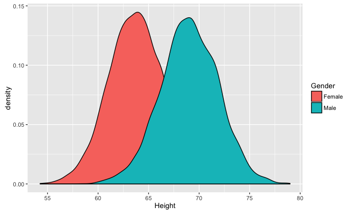

```r
library("ggplot2")
ggplot(df, aes(x = Height, fill = Gender)) + geom_density()
```

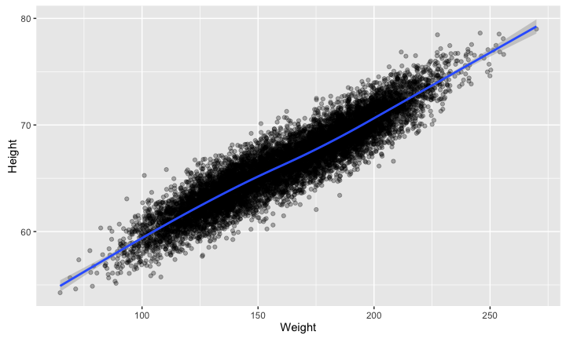

```r
ggplot(df, aes(x = Weight, y = Height)) + geom_point(alpha = .3) + geom_smooth()
```

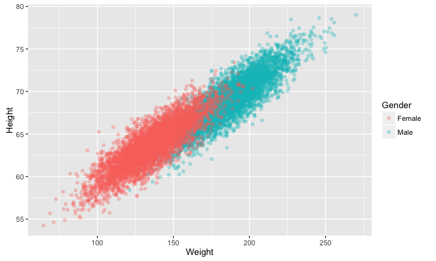

```r
ggplot(df, aes(x = Weight, y = Height, colour = Gender)) + geom_point(alpha = .3)
```

## Logit model

```r
df = df %>% mutate(gender = ifelse(Gender == "Male", 1, 0))
logit.model = glm(gender ~  Height + Weight, data = df, family = binomial(link = "logit"))
summary(logit.model)
```

```
##
## Call:
## glm(formula = gender ~ Height + Weight, family = binomial(link = "logit"),
##     data = df)
##
## Deviance Residuals:
##     Min       1Q   Median       3Q      Max
## -3.5073  -0.2211  -0.0006   0.2126   3.6794
##
## Coefficients:
##             Estimate Std. Error z value Pr(>|z|)
## (Intercept)  0.69254    1.32846   0.521    0.602
## Height      -0.49262    0.02896 -17.013   <2e-16 ***
## Weight       0.19834    0.00513  38.663   <2e-16 ***
## ---
## Signif. codes:  0 '***' 0.001 '**' 0.01 '*' 0.05 '.' 0.1 ' ' 1
##
## (Dispersion parameter for binomial family taken to be 1)
##
##     Null deviance: 13862.9  on 9999  degrees of freedom
## Residual deviance:  4182.6  on 9997  degrees of freedom
## AIC: 4188.6
##
## Number of Fisher Scoring iterations: 7
```

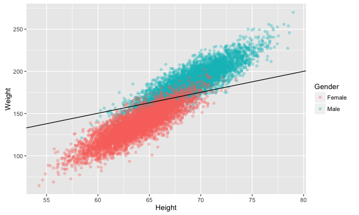

```r
ggplot(df, aes(x = Height, y = Weight)) + geom_point(aes(colour = Gender), alpha = .3) +
  geom_abline(intercept = - coef(logit.model)[1] / coef(logit.model)[2],
              slope = - coef(logit.model)[2] / coef(logit.model)[3],
              color = "black")
```

**Exercise**: How did I calculate the `intercept` and `slope`?

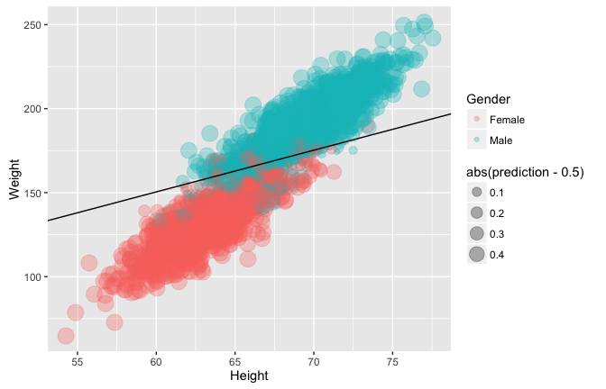

```r
df$prediction = logit.model$fitted.values
p = ggplot(sample_frac(df, .25), aes(x = Height, y = Weight)) +
  geom_point(aes(colour = Gender, size = abs(prediction - .5)), alpha = .3) +
  geom_abline(intercept = - coef(logit.model)[1] / coef(logit.model)[2],
              slope = - coef(logit.model)[2] / coef(logit.model)[3],
              color = "black")
```